# Assignment #3: Model Selection

#### 11/6/26

## Part 1: Model Modification and Selection

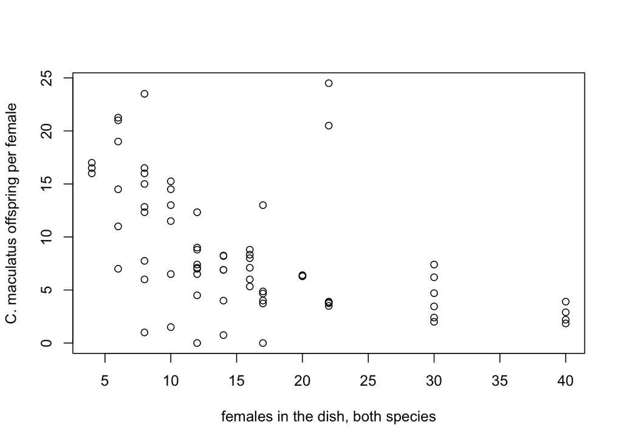

```r
# 1a: Competition between bean beetles ----------------------------------------

  # Seed beetles lay their eggs on beans, and the larvae develop inside them,
  # so beetles sharing a dish of beans compete for food. Each row is one dish:
  # a known number of females of two species placed on 2 g of beans, and the
  # number of offspring of each species that emerged.
  #
  # Here we model the offspring of Callosobruchus maculatus (species 1, "Cmac")
  # when it shares beans with Callosobruchus subinnotatus (species 2, "Csub").
  #
  #   start_females_1   C. maculatus females placed in the dish
  #   start_females_2   C. subinnotatus females placed in the dish
  #   progeny_1         C. maculatus offspring that emerged
  #
  # ?beetle_competition_interspecific describes the experiment.

  beetles <- beetle_competition_interspecific
  # or: beetles <- read.csv("https://github.com/bmaitner/biometry_course/raw/refs/heads/main/data/Beetle_competition/competition_interspecific.csv")

  beetles <- beetles[beetles$pair == "Cmac_Csub" & !is.na(beetles$progeny_1), ]

  # plot if you like: offspring per female against the number of competitors

  plot(beetles$start_females_1 + beetles$start_females_2,
       beetles$progeny_1 / beetles$start_females_1,
       xlab = "females in the dish, both species",
       ylab = "C. maculatus offspring per female")
```

```r
  # The starting model is a competition model in the Beverton-Holt family:
  #
  #   expected offspring = R * N1 / (1 + (a11 * N1 + a12 * N2)^d)
  #
  #   R     offspring per female with no competition at all
  #   a11   how much each C. maculatus female reduces that (within species)
  #   a12   how much each C. subinnotatus female reduces it (between species)
  #   d     how sharply competition bites as the dish fills up
  #   k     negative binomial size: how variable dishes are
  #
  # Bounds keep every parameter positive, so the optimizer cannot try
  # impossible values. If you remove a parameter, remove it from start, lower
  # and upper too.

  beetle.fit <- mle2(progeny_1 ~ dnbinom(mu = R * start_females_1 /
                                           (1 + (a11 * start_females_1 +
                                                 a12 * start_females_2)^d),
                                         size = k),
                      start = list(R = 20, a11 = 0.1, a12 = 0.1, d = 1, k = 2),
                      lower = c(R = 0.01, a11 = 0, a12 = 0, d = 0.1, k = 0.01),
                      upper = c(R = 1000, a11 = 10, a12 = 10, d = 10, k = 100),
                      method = "L-BFGS-B",
                      data = beetles)


  coef(beetle.fit)
```

```
##           R         a11         a12           d           k
## 15.77976150  0.10181406  0.03157821  1.59273834  3.25036024
```

```r
  AIC(beetle.fit)
```

```
## [1] 655.9222
```

```r
  # AIC = 655.922


  # Questions to build models around:
  #   - Is d needed? With d = 1 (leave it out of the formula) this is the
  #     classic Beverton-Holt model.
  beetle.fit2 <- mle2(progeny_1 ~ dnbinom(mu = R * start_females_1 /
                                           (1 + (a11 * start_females_1 +
                                                 a12 * start_females_2)),
                                         size = k),
                     start = list(R = 20, a11 = 0.1, a12 = 0.1, k = 2),
                     lower = c(R = 0.01, a11 = 0, a12 = 0, k = 0.01),
                     upper = c(R = 1000, a11 = 10, a12 = 10, k = 100),
                     method = "L-BFGS-B",
                     data = beetles)

  coef(beetle.fit2)
```

```
##          R        a11        a12          k
## 31.6272964  0.3249365  0.1151962  3.1978019
```

```r
  AIC(beetle.fit2)
```

```
## [1] 654.86
```

```r
  # AIC = 654.86


  #   - Does C. subinnotatus affect C. maculatus at all?
  #     (What value of a12 would mean "no"?) - a12 = 0, so remove?
  beetle.fit3 <- mle2(progeny_1 ~ dnbinom(mu = R * start_females_1 /
                                           (1 + (a11 * start_females_1 +
                                                 start_females_2)),
                                         size = k),
                      start = list(R = 20, a11 = 0.1, k = 2),
                      lower = c(R = 0.01, a11 = 0, k = 0.01),
                      upper = c(R = 1000, a11 = 10, k = 100),
                      method = "L-BFGS-B",
                      data = beetles)


  coef(beetle.fit3)
```

```
##          R        a11          k
## 174.131201   2.142004   3.036234
```

```r
  AIC(beetle.fit3) # AIC = 656.04
```

```
## [1] 656.0445
```

```r
  #   - Is a C. subinnotatus female as harmful as a C. maculatus female?
  #     (Hint: use one parameter for both.)
   beetle.fit4 <- mle2(progeny_1 ~ dnbinom(mu = R * start_females_1 /
                                           (1 + (a12 * start_females_1 +
                                                 a12 * start_females_2)),
                                         size = k),
                      start = list(R = 20, a12 = 0.1, k = 2),
                      lower = c(R = 0.01, a12 = 0, k = 0.01),
                      upper = c(R = 1000, a12 = 10, k = 100),
                      method = "L-BFGS-B",
                      data = beetles)


  coef(beetle.fit4)
```

```
##          R        a12          k
## 31.0917283  0.2091526  2.9206265
```

```r
  AIC(beetle.fit4)
```

```
## [1] 658.5367
```

```r
  # AIC = 658.54


  #   - A different shape: the Ricker model,
  #     R * N1 * exp(-a11 * N1 - a12 * N2). Is it nested in the starting model?

  beetle.fit5 <- mle2(progeny_1 ~ dnbinom(mu = R * start_females_1 *
                                               exp(-a11 * start_females_1 -
                                                    a12 * start_females_2),
                                         size = k),
                      start = list(R = 20, a11 = 0.1, a12 = 0.1, k = 2),
                      lower = c(R = 0.01, a11 = 0, a12 = 0, k = 0.01),
                      upper = c(R = 1000, a11 = 10, a12 = 10, k = 100),
                      method = "L-BFGS-B",
                      data = beetles)


  coef(beetle.fit5)
```

```
##           R         a11         a12           k
## 16.45632828  0.07289587  0.02121025  3.26011336
```

```r
  AIC(beetle.fit5)  # AIC = 653.72
```

```
## [1] 653.7268
```

```r
  # Compare model options
  AICtab(beetle.fit, beetle.fit2, beetle.fit3, beetle.fit4, beetle.fit5)
```

```
##             dAIC df
## beetle.fit5 0.0  4
## beetle.fit2 1.1  4
## beetle.fit  2.2  5
## beetle.fit3 2.3  3
## beetle.fit4 4.8  3
```

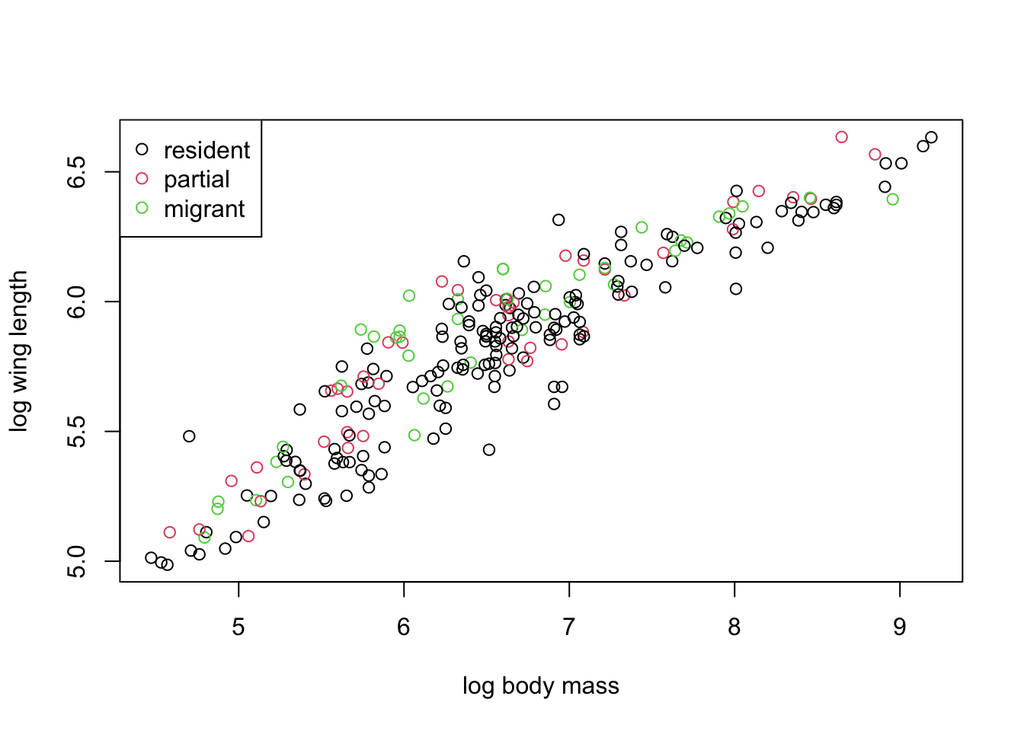

```r
# 1b: Wing length in hawks and eagles -----------------------------------------

  # Long-distance migrants should benefit from longer wings, which make
  # sustained flight cheaper. Do migratory hawks and eagles (family
  # Accipitridae) have longer wings than residents of the same body mass?
  #
  #   Wing.Length   mm
  #   Mass          g
  #   migration     resident, partial (some populations migrate), or migrant
  #
  # Each row is a species, so 249 species in all. One caution worth a
  # sentence in your answer: related species share traits, so species are not
  # fully independent data points. Accounting for that is beyond this course.

  hawks <- avonet
  # or: hawks <- readRDS(url("https://github.com/bmaitner/biometry_course/raw/refs/heads/main/data/Avonet/AVONET1_BirdLife.rds"))

  hawks <- hawks[hawks$Family1 == "Accipitridae", c("Species1", "Wing.Length", "Mass", "Migration")]
  hawks <- na.omit(hawks)
  hawks$migration <- factor(hawks$Migration, levels = 1:3,
                            labels = c("resident", "partial", "migrant"))

  # plot if you like

  plot(log(hawks$Mass), log(hawks$Wing.Length), col = hawks$migration,
       xlab = "log body mass", ylab = "log wing length")
  legend("topleft", levels(hawks$migration), col = 1:3, pch = 1)
```

```r
  # The starting model: wing length is lognormal, and its log rises linearly
  # with log mass. That is a power law, wing = e^int * mass^b, the usual way
  # one body measurement scales with another.
  #
  #   int     wing length at a given mass (on the log scale)
  #   b       how fast wing length rises with mass
  #   log_s   the log of the scatter around the line. Fitting the log keeps
  #           the standard deviation positive, as in Lecture 16
  #
  # parameters = lets every one of the three differ among the migration
  # classes, which is deliberately more than the data are likely to support.

  hawk.fit <- mle2(Wing.Length ~ dlnorm(meanlog = int + b * log(Mass),
                                        sdlog = exp(log_s)),
                   start = list(int = 3, b = 0.3, log_s = -2),
                   parameters = list(int ~ migration,
                                     b ~ migration,
                                     log_s ~ migration),
                   data = hawks)

  coef(hawk.fit)
```

```
##        int.(Intercept)   int.migrationpartial   int.migrationmigrant
##            3.615074770            0.013453348            0.192554685
##          b.(Intercept)     b.migrationpartial     b.migrationmigrant
##            0.334074109            0.007250078           -0.015011244
##      log_s.(Intercept) log_s.migrationpartial log_s.migrationmigrant
##           -1.962093245           -0.085641702            0.029384451
```

```r
  AIC(hawk.fit)
```

```
## [1] 2645.972
```

```r
  # AIC = 2645.972


  # Questions to build models around:
  #   - Do migrants have longer wings for their mass? (Which parameter is that?)
    hawk.fit2 <- mle2(Wing.Length ~ dlnorm(meanlog = int + b * log(Mass),
                                        sdlog = exp(log_s)),
                   start = list(int = 3, b = 0.3, log_s = -2),
                   parameters = list(int ~ migration),
                   data = hawks)

  coef(hawk.fit2)
```

```
##      int.(Intercept) int.migrationpartial int.migrationmigrant
##           3.62071604           0.06055444           0.09475141
##                    b                log_s
##           0.33321295          -1.96925831
```

```r
  AIC(hawk.fit2)
```

```
## [1] 2639.21
```

```r
  # AIC = 2639.21


  #   - Does wing length scale with mass differently in migrants?
    hawk.fit3 <- mle2(Wing.Length ~ dlnorm(meanlog = int + b * log(Mass),
                                        sdlog = exp(log_s)),
                   start = list(int = 3, b = 0.3, log_s = -2),
                   parameters = list(b ~ migration),
                   data = hawks)

  coef(hawk.fit3)
```

```
##                int      b.(Intercept) b.migrationpartial b.migrationmigrant
##        3.648574875        0.329101237        0.009218958        0.013786374
##              log_s
##       -1.967876374
```

```r
  AIC(hawk.fit3)
```

```
## [1] 2640.086
```

```r
  # AIC = 2640.086


  #   - Are some migration classes more variable than others?
  hawk.fit4 <- mle2(Wing.Length ~ dlnorm(meanlog = int + b * log(Mass),
                                        sdlog = exp(log_s)),
                   start = list(int = 3, b = 0.3, log_s = -2),
                   parameters = list(log_s ~ migration),
                   data = hawks)

  coef(hawk.fit4)
```

```
##                    int                      b      log_s.(Intercept)
##              3.6482480              0.3326635             -1.9477843
## log_s.migrationpartial log_s.migrationmigrant
##             -0.0590920              0.1259782
```

```r
  AIC(hawk.fit4)
```

```
## [1] 2655.095
```

```r
  # AIC = 2655.095


  #   - Is the distinction between partial migrants and full migrants needed,
  #     or would migrant versus resident do? (You would need a new column.)

  hawks_edit <- hawks|>
                mutate(migration_edit = if_else(Migration == 1, "resident", "migrant"))

  hawk.fit5 <- mle2(Wing.Length ~ dlnorm(meanlog = int + b * log(Mass),
                                        sdlog = exp(log_s)),
                   start = list(int = 3, b = 0.3, log_s = -2),
                   parameters = list(int ~ migration_edit),
                   data = hawks_edit)

  coef(hawk.fit5)
```

```
##            int.(Intercept) int.migration_editresident
##                 3.69779054                -0.07692085
##                          b                      log_s
##                 0.33319441                -1.96714312
```

```r
  AIC(hawk.fit5) # AIC = 2638.46
```

```
## [1] 2638.457
```

```r
  # Compare model options
  AICtab(hawk.fit, hawk.fit2, hawk.fit3, hawk.fit4, hawk.fit5)
```

```
##           dAIC df
## hawk.fit5  0.0 4
## hawk.fit2  0.8 5
## hawk.fit3  1.6 5
## hawk.fit   7.5 9
## hawk.fit4 16.6 5
```

Out of the five candidate models shown above, I would choose hawk.fit5 as the best model for this data. Based on the log-transformed plot of wing length by body mass and expectation that wing length should generally scale with body mass, the starting model’s power-law seems to be an appropriate function for this data. However, hawk.fit5 simplifies the starting model by first limiting int as the only parameter that varies with migration status and then removing the distinction between partial and full migrants. It’s important to note that while hawk.fit5 is the best candidate model, it does not account for the fact that the data points aren’t fully independent of each other because related species share traits. One possible solution for this problem could be to combine closely related species and then compare mean wing length and body masses between these subgroups.

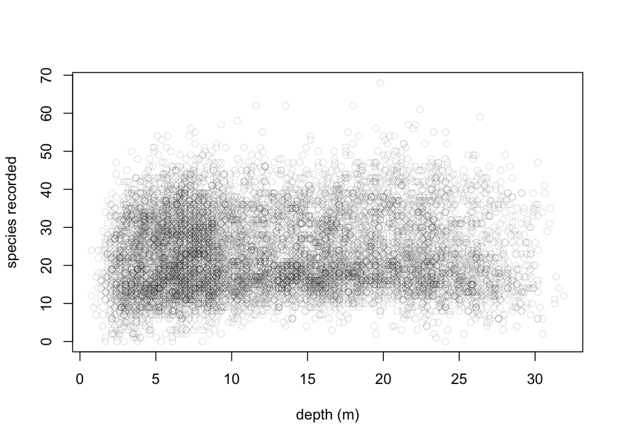

```r
# 1c: Reef fish species richness ----------------------------------------------

  # How many fish species does a diver record on a survey of a Florida coral
  # reef, and what explains the differences?
  #
  #   species_richness   number of species recorded on the survey
  #   depth              tens of metres (so 1.5 is 15 m)
  #   visibility         underwater visibility, tens of metres
  #   year               years since 2014
  #   region             Tortugas, Keys, or North (Miami to Martin County)
  #   protected          "yes" inside a marine protected area, otherwise "no"
  #
  # Depth and visibility are in tens of metres because depth is squared in
  # the model, and squaring 30 m gives numbers large enough to stall the
  # optimizer. Rescaling a covariate changes nothing about the biology.

  reef <- reef_fish_surveys
  # or: reef <- read.csv("https://github.com/bmaitner/biometry_course/raw/refs/heads/main/data/Reef_fish/NCRMP_reef_fish_surveys.csv")

  reef$depth <- reef$DEPTH / 10
  reef$visibility <- reef$UNDERWATER_VISIBILITY / 10
  reef$year <- reef$YEAR - 2014
  reef$region <- factor(reef$REGION_DESCRIPTION,
                        levels = c("Dry Tortugas",
                                   "Florida Keys: from Key West to Miami",
                                   "Miami to North Martin County"),
                        labels = c("Tortugas", "Keys", "North"))
  reef$protected <- ifelse(reef$MPA_NAME == "Unprotected", "no", "yes")

  # plot if you like

  plot(reef$DEPTH, reef$species_richness, col = rgb(0, 0, 0, 0.1),
       xlab = "depth (m)", ylab = "species recorded")
```

```r
  # The starting model: richness is Poisson, its log rises and then falls
  # with depth (the d2 * depth^2 term makes a hump), and it also depends on
  # visibility, year, region and protection.

  reef.fit <- mle2(species_richness ~ dpois(lambda = exp(int +
                                                         d1 * depth +
                                                         d2 * depth^2 +
                                                         v * visibility +
                                                         t * year)),
                   start = list(int = 3, d1 = 0, d2 = 0, v = 0, t = 0),
                   parameters = list(int ~ region + protected),
                   data = reef)

  coef(reef.fit)
```

```
##  int.(Intercept)   int.regionKeys  int.regionNorth int.protectedyes
##      2.440431321      0.320959554      0.303412405      0.068348842
##               d1               d2                v                t
##      0.461964707     -0.134033578      0.126784652      0.005063466
```

```r
  AIC(reef.fit) # AIC = 76092.11
```

```
## [1] 76092.11
```

```r
  # Questions to build models around:
  #   - Is the Poisson the right distribution? Check before anything else:
  #     what did Lecture 15 use var() / mean() for? - to check for clumping

  var(reef$species_richness)/mean(reef$species_richness)
```

```
## [1] 4.43347
```

```r
  reef.fit2 <- mle2(species_richness ~ dnbinom(mu = exp(int +
                                                         d1 * depth +
                                                         d2 * depth^2 +
                                                         v * visibility +
                                                         t * year),
                                                       size = exp(log_phi)),
                   start = list(int = 3, d1 = 0, d2 = 0, v = 0, t = 0, log_phi = 0),
                   parameters = list(int ~ region + protected),
                   data = reef)

  coef(reef.fit2)
```

```
##  int.(Intercept)   int.regionKeys  int.regionNorth int.protectedyes
##      2.429467035      0.323120940      0.301883546      0.067094746
##               d1               d2                v                t
##      0.465042775     -0.134071396      0.127186563      0.006561079
##          log_phi
##      2.012147552
```

```r
  AIC(reef.fit2) # AIC = 62609.9
```

```
## [1] 62609.9
```

```r
  #   - With 8,560 surveys, AIC may keep nearly every term. If so, which
  #     effects are large enough to matter? Back-transform them: exp() of a
  #     coefficient is the multiplier on expected richness.
   reef.fit3a <- mle2(species_richness ~ dnbinom(mu = int +
                                                         d1 * depth +
                                                         d2 * depth^2 +
                                                         v * visibility +
                                                         t * year,
                                                       size = exp(log_phi)),
                   start = list(int = 3, d1 = 0, d2 = 0, v = 0, t = 0, log_phi = 0),
                   parameters = list(int ~ region + protected),
                   method = "L-BFGS-B",
                   data = reef)

   AIC(reef.fit3a) # AIC = 62601.39
```

```
## [1] 62601.4
```

```r
    reef.fit3b <- mle2(species_richness ~ dnbinom(mu = int +
                                                         exp(d1) * depth +
                                                         exp(d2) * depth^2 +
                                                         exp(v) * visibility +
                                                         exp(t) * year,
                                                       size = exp(log_phi)),
                   start = list(int = 3, d1 = 0, d2 = 0, v = 0, t = 0, log_phi = 0),
                   parameters = list(int ~ region + protected),
                   method = "L-BFGS-B",
                   data = reef)

  coef(reef.fit3b)
```

```
##  int.(Intercept)   int.regionKeys  int.regionNorth int.protectedyes
##        12.537390         6.228924         6.435738         1.064841
##               d1               d2                v                t
##         0.368030        -6.919486         1.148943        -1.630800
##          log_phi
##         1.983385
```

```r
  AIC(reef.fit3b) # AIC = 62788.64 (I don't think I did this right)
```

```
## [1] 62788.64
```

```r
  #   - Visibility is a property of the water on the day, not of the reef.
  #     What might a visibility effect be measuring? - tied to depth?

    reef.fit4 <- mle2(species_richness ~ dnbinom(mu = exp(int +
                                                         d1 * depth +
                                                         d2 * depth^2 +
                                                         t * year),
                                                       size = exp(log_phi)),
                   start = list(int = 3, d1 = 0, d2 = 0, t = 0, log_phi = 0),
                   parameters = list(int ~ region + protected),
                   data = reef)

  coef(reef.fit4)
```

```
##  int.(Intercept)   int.regionKeys  int.regionNorth int.protectedyes
##      2.532325894      0.317241233      0.317725853      0.078416371
##               d1               d2                t          log_phi
##      0.497181350     -0.137480058      0.007489357      1.984584548
```

```r
  AIC(reef.fit4) # AIC = 62779.82
```

```
## [1] 62779.82
```

```r
  #   - Does protection matter once region is accounted for?
    reef.fit5 <- mle2(species_richness ~ dnbinom(mu = exp(int +
                                                         d1 * depth +
                                                         d2 * depth^2 +
                                                         v * visibility +
                                                         t * year),
                                                       size = exp(log_phi)),
                   start = list(int = 3, d1 = 0, d2 = 0, v = 0, t = 0, log_phi = 0),
                   parameters = list(int ~ region),
                   data = reef)

  coef(reef.fit5)
```

```
## int.(Intercept)  int.regionKeys int.regionNorth              d1              d2
##      2.47939017      0.30587864      0.26411096      0.44095862     -0.12730014
##               v               t         log_phi
##      0.13203981      0.00641634      2.00609908
```

```r
  AIC(reef.fit5) # AIC = 62645.47
```

```
## [1] 62645.47
```

```r
  # Compare candidate models
  AICtab(reef.fit, reef.fit2, reef.fit3a, reef.fit3b, reef.fit4, reef.fit5)
```

```
##            dAIC    df
## reef.fit3a     0.0 9
## reef.fit2      8.5 9
## reef.fit5     44.1 8
## reef.fit4    178.4 8
## reef.fit3b   187.2 9
## reef.fit   13490.7 8
```

## Part 2: Focal Dataset Model Selection

```r
## R script to load in and clean CREMP Octo data for use in Biometry assignments

# Read in datasets--------------------------------------------

octo_tally_master <- read.csv("https://raw.githubusercontent.com/caroline-link/Biometry/refs/heads/main/CREMP_OCTO_Data/CREMP_OCTO_Tallies_Masterfile.csv")

octo_conditions_master <- read.csv("https://raw.githubusercontent.com/caroline-link/Biometry/refs/heads/main/CREMP_OCTO_Data/CREMP_OCTO_Condition_Masterfile.csv")


# Clean tally dataset-----------------------------------------------------------

# Subset to observations from 2012-2025
tally <- octo_tally_master |>
         filter(SampleYear > 2011)

# Remove unnecessary metadata columns (PointCount site code, Transect, AbbrName, SciName)
# unique(tally$TRANSECT) - check that all data was collected from transect 300
tally <- tally[-c(6,10:12)]

# Rename "Subregion" column to "SubRegion", "Tally" to "Tally_AllSpecies", and Density" to "Density_AllSpecies"
tally <- tally |>
         rename(SubRegion = Subregion,
                Tally_AllSpecies = Tally,
                Density_AllSpecies = Density)

# Recode DRTO pinnacle sites
tally <- tally |>
         mutate(Habitat = case_when(
          SiteName == "The Maze" ~ "PIN",
          SiteName == "Davis Rock" ~ "PIN",
          SiteName == "Texas Rock" ~ "PIN",
          SiteName == "Temptation Rock" ~ "PIN",
          SiteName == "Mayer's Peak" ~ "PIN",
          SiteName == "Black Coral Rock" ~ "PIN",
          TRUE ~ Habitat))

# Set SiteID and StationID as factors
tally <- tally |>
         mutate(SiteID = as.factor(SiteID),
                StationID = as.factor(StationID))


# Clean conditions dataset------------------------------------------------------

# Subset to observations from 2012-2025
conditions <- octo_conditions_master |>
              filter(SampleYear > 2011)

# Remove conditions and unnecessary metadata columns (recorder, PointCount site code, transect)
# unique(conditions$TRANSECT)  - check that all data was collected from transect 300
conditions <- conditions[-c(4, 7, 11, 14:40)]

# Rename columns to match tally dataset
conditions <- conditions|>
              rename(FirstSampleDate = Date,
                     SubRegion = subRegionId,
                     Habitat = habitatid,
                     SiteID = siteid,
                     SiteName = sitename)

# Limit to current CREMP target species, update species codes (including combining NS-PAME and PAME)
targets <- conditions |>
           filter(SPP_Code %in% c("PAME",
                                 "NS-PAME",
                                 "PFLE",
                                 "GVEN",
                                 "PBIP",
                                 "PPOR")) |>
          mutate(SPP_Code = recode(SPP_Code,
                                   "NS-PAME" = "AAME",
                                   "PAME" = "AAME",
                                   "PFLE" = "EFLE",
                                   "PBIP" = "ABIP"))

# Check that counts of NS-PAME and PAME are equal to combined AAME count
#conditions|>
# filter(SPP_Code %in% c("PAME", "NS-PAME")) |>
#  nrow()

#targets|>
# filter(SPP_Code == "AAME") |>
#  nrow()

# Recode DRTO pinnacle sites
targets <- targets |>
           mutate(Habitat = case_when(
           SiteName == "The Maze" ~ "PIN",
           SiteName == "Davis Rock" ~ "PIN",
           SiteName == "Texas Rock" ~ "PIN",
           SiteName == "Temptation Rock" ~ "PIN",
           SiteName == "Mayer's Peak" ~ "PIN",
           SiteName == "Black Coral Rock" ~ "PIN",
           TRUE ~ Habitat))

# Set SiteID and StationID as factors
targets <- targets |>
           mutate(SiteID = as.factor(SiteID),
                  StationID = as.factor(StationID))

# Confirm that sites are coded properly

# Find number of sites in each region
#targets |>
#  group_by(SubRegion) |>
#  summarise(sites_per_region = n_distinct(SiteName))

# Return list of sites in each region
#targets |>
#  group_by(SubRegion, Habitat) |>
#  summarise(type = paste(sort(unique(SiteName, Habitat)), collapse = ", "))

# Liberman et al. 2025 used the same dataset and had 20 sites in the FL Keys (LK = 6 MK = 8, UK = 6) and 7 sites in DRTO.
# removed from DRTO: Davis Rock, Palmata Patch, Loggerhead Patch, Texas Rock
# removed from LK: Red Dun


# Create summary table with total and target counts/densities per transect---------

# Add columns to targets with target count and density per transect
combined_targets <- targets |>
                    group_by(SampleYear, StationID) |>
                    summarise(Tally_Targets = n(),
                              Density_Targets = n()/10)
```

[output not shown]

```r
# Join to tally dataset to get full grid of transects/years
combined <- left_join(tally, combined_targets, by = c("SampleYear", "StationID"))

# Replace NAs introduced for sites w/o targets
combined$Tally_Targets[is.na(combined$Tally_Targets)] <- 0.0
combined$Density_Targets[is.na(combined$Density_Targets)] <- 0.0

# Transects w/o targets
no_targets <- combined |>
              filter(Tally_Targets == 0) |>
              group_by(SampleYear, StationID)

subset(combined, is.na(combined$SPP_Code)) |>
              group_by(SampleYear,StationID)
```

```
## # A tibble: 0 × 12
## # Groups:   SampleYear, StationID [0]
## # ℹ 12 variables: SampleYear <int>, FirstSampleDate <chr>, ProjectRegion <chr>,
## #   SubRegion <chr>, Habitat <chr>, SiteID <fct>, SiteName <chr>,
## #   StationID <fct>, Tally_AllSpecies <int>, Density_AllSpecies <dbl>,
## #   Tally_Targets <dbl>, Density_Targets <dbl>
```

```r
# Sites w/o any octos
no_octos <- no_targets|>
            filter(Tally_AllSpecies == 0) |>
            group_by(SampleYear, SiteID)

# Does Davis ever have octos?
filter(combined, SiteID == 28, Tally_AllSpecies > 0)
```

```
##   SampleYear FirstSampleDate ProjectRegion SubRegion Habitat SiteID   SiteName
## 1       2013      2013-05-31         NPSDT        DT     PIN     28 Davis Rock
## 2       2018      2018-09-11         NPSDT        DT     PIN     28 Davis Rock
## 3       2019      2019-08-13         NPSDT        DT     PIN     28 Davis Rock
## 4       2019      2019-08-13         NPSDT        DT     PIN     28 Davis Rock
## 5       2023      2023-08-12         NPSDT        DT     PIN     28 Davis Rock
##   StationID Tally_AllSpecies Density_AllSpecies Tally_Targets Density_Targets
## 1       281                1                0.1             0             0.0
## 2       281                3                0.3             0             0.0
## 3       281                3                0.3             0             0.0
## 4       283                1                0.1             0             0.0
## 5       284                1                0.1             1             0.1
```

```r
## Only 9 colonies counted between 2012-2025, think about removing site as an outlier
```

**Target Species Count Data Exploration**

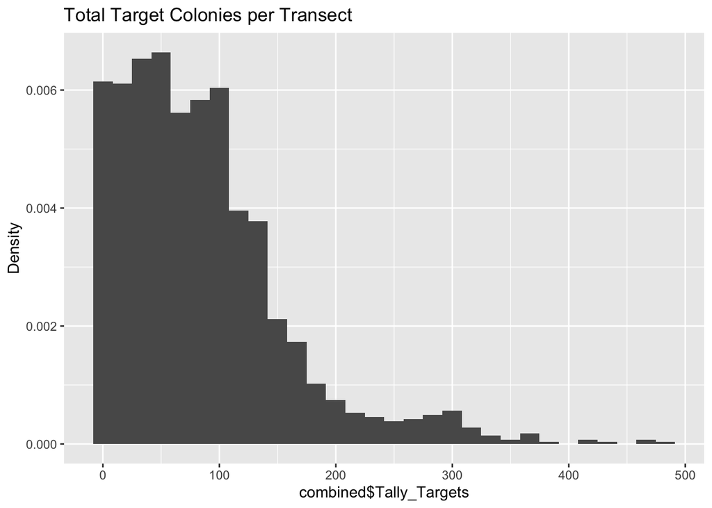

```r
# Plot target species counts per transect per year
ggplot(mapping = aes(combined$Tally_Targets)) +
    geom_histogram(aes(y = after_stat(density)), bins = 30) +
  labs(title = bquote("Total Target Colonies per Transect"),
       y = "Density")
```

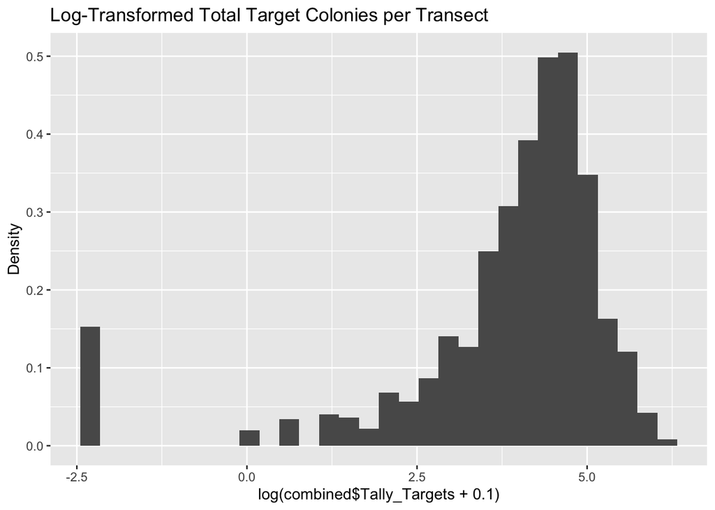

```r
# See if log-transforming target counts helps (added + 0.1 to account for issues with log(0))
ggplot(mapping = aes(log(combined$Tally_Targets + 0.1))) +
    geom_histogram(aes(y = after_stat(density)), bins = 30) +
  labs(title = bquote("Log-Transformed Total Target Colonies per Transect"),
       y = "Density")
```

```r
# Check mean/median/var
mean(log(combined$Tally_Targets + 0.1))
```

```
## [1] 3.804734
```

```r
median(log(combined$Tally_Targets + 0.1))
```

```
## [1] 4.278054
```

```r
var(log(combined$Tally_Targets + 0.1)) / mean(log(combined$Tally_Targets + 0.1))
```

```
## [1] 0.7375785
```

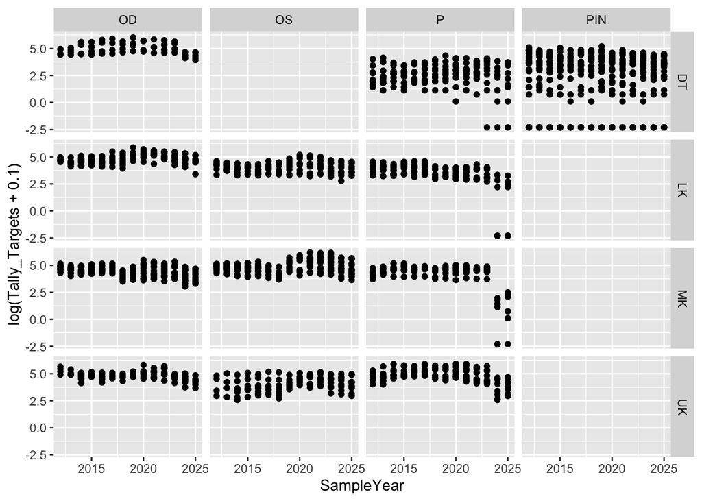

```r
# variance/mean = 0.7

# Scatterplot of target count
combined |>
  ggplot(mapping = aes(x = SampleYear, y = log(Tally_Targets + 0.1))) +
  geom_point() +
  facet_grid(SubRegion ~ Habitat)
```

**Candidate Models**

```r
# Center year
combined$SampleYear <- combined$SampleYear - min(combined$SampleYear)

# Find starting parameter for target tally
start_target_tally <- log(mean(combined$Tally_Targets + 0.1))

# Target count candidate models
target_pois1 <-mle2(Tally_Targets ~ dpois(
                                    lambda = exp(tally + b_yr * SampleYear)),
                    start = list(tally = start_target_tally, b_yr = 0),
                    data = combined)

target_nb1 <-mle2(Tally_Targets ~ dnbinom(
                                  mu = exp(tally + b_yr * SampleYear),
                                  size = exp(log_k)),
                   start = list(tally = start_target_tally, b_yr = 0, log_k = 0),
                   data = combined)

AICtab(target_pois1, target_nb1)
```

```
##              dAIC    df
## target_nb1       0.0 3
## target_pois1 90006.5 2
```

```r
# Negative binomial fit better, try letting parameters differ based on site characteristics
target_nb2 <- mle2(Tally_Targets ~ dnbinom(
                                  mu = exp(tally + b_yr * SampleYear),
                                  size = exp(log_k)),
                   start = list(tally = start_target_tally, b_yr = 0, log_k = 0),
                   parameters = list(tally ~ SiteID),
                   data = combined)


target_nb3 <- mle2(Tally_Targets ~ dnbinom(
                                  mu = exp(tally + b_yr * SampleYear),
                                  size = exp(log_k)),
                   start = list(tally = start_target_tally, b_yr = 0, log_k = 0),
                   parameters = list(tally ~ Habitat),
                   data = combined)

target_nb4 <- mle2(Tally_Targets ~ dnbinom(
                                   mu = exp(tally + b_yr * SampleYear),
                                   size = exp(log_k)),
                   start = list(tally = start_target_tally, b_yr = 0, log_k = 0),
                   parameters = list(tally ~ Habitat + SubRegion),
                   data = combined)

AICtab(target_nb1, target_nb2, target_nb3, target_nb4)
```

```
##            dAIC   df
## target_nb2    0.0 34
## target_nb4 2022.3 9
## target_nb3 2173.7 6
## target_nb1 2467.6 3
```

```r
# Habitat and SubRegion are accounted for by SiteID, try adding a new parameter
target_nb5 <- mle2(Tally_Targets ~ dnbinom(
                                  mu = exp(tally + b_yr * SampleYear),
                                  size = exp(log_k)),
                   start = list(tally = start_target_tally, b_yr = 0, log_k = 0),
                   parameters = list(tally ~ SiteID, log_k ~ SubRegion),
                   method = "L-BFGS-B",
                   data = combined)
# convergence failure

AICtab(target_nb1, target_nb2, target_nb3, target_nb4, target_nb5)
```

```
##            dAIC   df
## target_nb2    0.0 34
## target_nb5   23.7 37
## target_nb4 2022.3 9
## target_nb3 2173.7 6
## target_nb1 2467.6 3
```

Of the models shown above, I would choose target_nb2 as the best model for predicting the number of target octocoral colonies observed at a given transect on a given year. Since dataset is made up of count data and the distribution is made more normal by log-transformation, a negative binomial seemed to be a strong fit for the distribution, which I confirmed by comparing the AICs of target_pois1 and target_nb1. I then tried to improve target_nb1 by allowing the tally parameter to differ based on site, habitat, and subregion. Target_nb2, which allowed the tally parameter to vary by site, resulted in the lowest AIC. This makes intuitive sense it allows for variation at the most specified level and site-level variances also inherently account for habitat and subregion effects.